# TFA exam - Guiding solution

Lars Relund Nielsen

# R - Assignment 1 (55%)

Consider the dataset in the file `catch.csv` containing catches from rivers in Denmark. A row is given for each catch with information about weight, length, date, angler, place, method etc.

Some of the columns/variables are:

- `Date`: Date of catch.
- `Length`: Length of fish (cm).
- `Weight`: Weight of fish (kilograms).
- `Place`: Place of catch (Lower, Middle, Upper).
- `Method`: Method used (Spin, Fly, Worm).
- `Killed`: If the fish was killed.
- `River`: River of catch.
- `Species`: Species of fish.
- `Name`: Name of angler.

The dataset can be read using:

```r
library(tidyverse)
dat <- read_csv("catch.csv")
```

Moreover, consider the dataset in the file `weight.csv` containing weight estimates for a given length. A row is given for each length with information about weight, month, river, species etc.

Some of the columns/variables are:

- `Length`: Length of fish (cm).
- `Month`: Month considered.
- `Avg`: Average weight of fish (kilograms).
- `Lower`: Lower confidence interval weight (kilograms).
- `Upper`: Uppper confidence interval weight (kilograms).

The dataset can be read using:

```r
library(tidyverse)
dat_weight <- read_csv("weight.csv")
res <- dat_weight |>
   filter(River == "Karup",
          Species == "Seatrout",
          Length == 50,
          Month == 5) |>
   print()
```

```
## # A tibble: 1 × 7
##   Length   Avg Lower Upper Month River Species
##    <dbl> <dbl> <dbl> <dbl> <dbl> <chr> <chr>
## 1     50  1.54  1.24  1.92     5 Karup Seatrout
```

That is, for instance, the average weight of a 50 cm seatrout in Karup River in May is 1.54 kg with a 95% confidence interval of [1.24, 1.92] kg.

Use the *dplyr* package in *tidyverse* to calculate relevant summary tables (tibbles/data frames), and answer/complete the following questions/tasks:

## Question 1

Which method resulted in most fish caught in Skjern River?

```r
res <- dat |>
   filter(River == "Skjern") |>
   group_by(Method) |>
   summarize(
      n_caught = n()
   ) |>
   arrange(desc(n_caught)) |>
   print()
```

```
## # A tibble: 3 × 2
##   Method n_caught
##   <chr>     <int>
## 1 Fly        9425
## 2 Spin       8933
## 3 Worm        359
```

The method that caught most fish in Skjern River is Fly with 9425 fish caught.

## Question 2

Which angler has caught most fish in total and in kilograms over all the years considered?

```r
res <- dat |>
   group_by(Name) |>
   summarize(
      total_weight = sum(Weight, na.rm = TRUE),
      n_caught = n()
   ) |>
   arrange(desc(total_weight)) |>
   print()
```

```
## # A tibble: 4,854 × 3
##    Name                         total_weight n_caught
##    <chr>                               <dbl>    <int>
##  1 Grete Danielsen-Christiansen         306.      101
##  2 Bent Kjær                            296.      146
##  3 Univ.Prof. Nanni Nielsen             281.      101
##  4 Nicolai Carlsen                      278.       99
##  5 Ulf Dahl                             266.       81
##  6 Prof. Hjalte Thygesen                259.      159
##  7 Paul Klausen                         244.       88
##  8 Peder Thorsen-Carlsen                224.      157
##  9 Åge Ravn-Overgaard                   214.       78
## 10 Dagny Thygesen                       211.      111
## # ℹ 4,844 more rows
```

```r
res2 <- res |>
   arrange(desc(n_caught)) |>
   print()
```

```
## # A tibble: 4,854 × 3
##    Name                       total_weight n_caught
##    <chr>                             <dbl>    <int>
##  1 Prof. Paula Krogh                  26.4      198
##  2 Prof. Hjalte Thygesen             259.       159
##  3 Peder Thorsen-Carlsen             224.       157
##  4 René Larsen                       117.       153
##  5 Tage Clausen-Kristoffersen         63.8      147
##  6 Bent Kjær                         296.       146
##  7 Richard Paulsen                    81.9      143
##  8 Albert Knudsen                     34.6      131
##  9 Jano Kjær                          90.3      124
## 10 Sofia Andersen                     43.3      114
## # ℹ 4,844 more rows
```

The angler Grete Danielsen-Christiansen have caught and killed the highest total weight of 306.49 kilograms over all the years considered. The angler Prof. Paula Krogh have caught the highest number of fish of 198 over all the years considered.

## Question 3

Calculate the condition factor for each fish using the formula `Weight*100000/Length^3`.

```r
res <- dat |>
   mutate(Condition = Weight*100000/Length^3) |>
   print()
```

```
## # A tibble: 29,268 × 15
##    Date       Length Weight Place  Method Killed Sex   River Species  Name      Year Month
##    <date>      <dbl>  <dbl> <chr>  <chr>  <lgl>  <chr> <chr> <chr>    <chr>    <dbl> <dbl>
##  1 2015-03-01     58  1.56  Middle Spin   TRUE   <NA>  Karup Seatrout Fru Fri…  2015     3
##  2 2015-03-01     64  2.10  Middle Worm   TRUE   <NA>  Karup Seatrout Mille S…  2015     3
##  3 2015-03-01     53  1.5   Lower  Worm   TRUE   <NA>  Karup Seatrout Thomas …  2015     3
##  4 2015-03-01     59  1.64  Lower  Worm   TRUE   <NA>  Karup Seatrout Alex Kn…  2015     3
##  5 2015-03-01     45  0.729 Lower  Worm   TRUE   <NA>  Karup Seatrout Øjvind …  2015     3
##  6 2015-03-01     44  0.95  Lower  Worm   TRUE   <NA>  Karup Seatrout Prof. L…  2015     3
##  7 2015-03-01     41  0.7   Lower  Worm   TRUE   <NA>  Karup Seatrout Elna Ra…  2015     3
##  8 2015-03-01     52  1.12  Lower  Worm   TRUE   <NA>  Karup Seatrout Elna Ra…  2015     3
##  9 2015-03-01     63  2.00  Lower  Worm   TRUE   <NA>  Karup Seatrout Hjalte …  2015     3
## 10 2015-03-01     71  2.86  Lower  Worm   TRUE   <NA>  Karup Seatrout Dr. Joh…  2015     3
## # ℹ 29,258 more rows
## # ℹ 3 more variables: Week <dbl>, Weekday <chr>, Condition <dbl>
```

Is the average condition factor higher for salmon or seatrout?

```r
res1 <- res |>
   group_by(Species) |>
   summarize(
      avg_Condition = mean(Condition, na.rm = TRUE)
   ) |>
   arrange(desc(avg_Condition)) |>
   print()
```

```
## # A tibble: 2 × 2
##   Species  avg_Condition
##   <chr>            <dbl>
## 1 Seatrout         1.18
## 2 Salmon           0.974
```

The average condition factor is highest for Seatrout with an average of 1.18.

Consider the months after April and fish with a weight above 50 cm. Do seatrout in Karup River have a higher average condition factor than seatrout in Skjern River?

```r
res2 <- res |>
   filter(Species == "Seatrout", Month > 4, Length > 50) |>
   group_by(River) |>
   summarize(
      n = n(),
      avg_Condition = mean(Condition, na.rm = TRUE)
   ) |>
   arrange(desc(avg_Condition)) |>
   print()
```

```
## # A tibble: 2 × 3
##   River      n avg_Condition
##   <chr>  <int>         <dbl>
## 1 Skjern  2996          1.19
## 2 Karup   7465          1.19
```

The condition factor seems to be the same.

## Question 4

Are there more catches per day on average on weekdays or during weekends in Skjern River?

```r
res <- dat |>
   filter(River == "Skjern") |>
   mutate(day_type = if_else(Weekday %in% c("Saturday", "Sunday"), "Weekend", "Weekday")) |>
   group_by(day_type) |>
   summarize(
      n_caught = n(),
      n_days = n_distinct(Date),
      avg_catches_per_day = n_caught / n_days
   ) |>
   ungroup() |>
   print()
```

```
## # A tibble: 2 × 4
##   day_type n_caught n_days avg_catches_per_day
##   <chr>       <int>  <int>               <dbl>
## 1 Weekday     12854   1128                11.4
## 2 Weekend      5863    458                12.8
```

There are more catches per day on average on weekends in Skjern River.

## Question 5

Calculate the catch and release rate (number released / total number caught) for each river over all years. Have the catch and release rates increased over the years in Karup River?

```r
res <- dat |>
   group_by(River, Year) |>
   summarize(
      n_caught = n(),
      n_released = sum(!Killed)
   ) |>
   mutate(catch_release_rate = n_released / n_caught) |>
   ungroup() |>
   print()
```

```
## # A tibble: 18 × 5
##    River   Year n_caught n_released catch_release_rate
##    <chr>  <dbl>    <int>      <int>              <dbl>
##  1 Karup   2015     2359          0             0
##  2 Karup   2016     1630          0             0
##  3 Karup   2017     1090        260             0.239
##  4 Karup   2018      756        162             0.214
##  5 Karup   2019      665         51             0.0767
##  6 Karup   2020     1224        295             0.241
##  7 Karup   2021      985        323             0.328
##  8 Karup   2022      751        259             0.345
##  9 Karup   2023     1091        357             0.327
## 10 Skjern  2015     2623       2001             0.763
## 11 Skjern  2016     1860       1386             0.745
## 12 Skjern  2017     1964       1549             0.789
## 13 Skjern  2018     2231       1712             0.767
## 14 Skjern  2019     2019       1633             0.809
## 15 Skjern  2020     2099       1578             0.752
## 16 Skjern  2021     1761       1377             0.782
## 17 Skjern  2022     2243       1881             0.839
## 18 Skjern  2023     1917       1613             0.841
```

```r
res2 <- res |>
   filter(River == "Karup") |>
   select(Year, catch_release_rate) |>
   arrange(Year) |>
   print()
```

```
## # A tibble: 9 × 2
##    Year catch_release_rate
##   <dbl>              <dbl>
## 1  2015             0
## 2  2016             0
## 3  2017             0.239
## 4  2018             0.214
## 5  2019             0.0767
## 6  2020             0.241
## 7  2021             0.328
## 8  2022             0.345
## 9  2023             0.327
```

## Question 6

Use the weight dataset to update missing weights in the catch dataset. That is, for each fish, with a missing weight, use the average weight from the weight dataset for the corresponding length, river, species and month. Hint: Before joining the datasets, you need to round the length to an integer.

```r
dat_full <- dat |>
   mutate(Length = round(Length)) |>
   left_join(dat_weight) |>
   mutate(
      Weight = if_else(is.na(Weight), Avg, Weight)
   ) |>
   print()
```

```
## # A tibble: 29,268 × 17
##    Date       Length Weight Place  Method Killed Sex   River Species  Name      Year Month
##    <date>      <dbl>  <dbl> <chr>  <chr>  <lgl>  <chr> <chr> <chr>    <chr>    <dbl> <dbl>
##  1 2015-03-01     58  1.56  Middle Spin   TRUE   <NA>  Karup Seatrout Fru Fri…  2015     3
##  2 2015-03-01     64  2.10  Middle Worm   TRUE   <NA>  Karup Seatrout Mille S…  2015     3
##  3 2015-03-01     53  1.5   Lower  Worm   TRUE   <NA>  Karup Seatrout Thomas …  2015     3
##  4 2015-03-01     59  1.64  Lower  Worm   TRUE   <NA>  Karup Seatrout Alex Kn…  2015     3
##  5 2015-03-01     45  0.729 Lower  Worm   TRUE   <NA>  Karup Seatrout Øjvind …  2015     3
##  6 2015-03-01     44  0.95  Lower  Worm   TRUE   <NA>  Karup Seatrout Prof. L…  2015     3
##  7 2015-03-01     41  0.7   Lower  Worm   TRUE   <NA>  Karup Seatrout Elna Ra…  2015     3
##  8 2015-03-01     52  1.12  Lower  Worm   TRUE   <NA>  Karup Seatrout Elna Ra…  2015     3
##  9 2015-03-01     63  2.00  Lower  Worm   TRUE   <NA>  Karup Seatrout Hjalte …  2015     3
## 10 2015-03-01     71  2.86  Lower  Worm   TRUE   <NA>  Karup Seatrout Dr. Joh…  2015     3
## # ℹ 29,258 more rows
## # ℹ 5 more variables: Week <dbl>, Weekday <chr>, Avg <dbl>, Lower <dbl>, Upper <dbl>
```

# R - Assignment 2 (45%)

Answer this assignment using the *ggplot2* package in *tidyverse* (you may need *dplyr* for preparing the datasets you want to plot). We use the same dataset as given in Assignment 1 if not specified.

## Question 1

Create a visualization showing the average weight of seatrout in Karup River over the months with the following features:

- Use the dataset from Assignment 1 in which missing weights have been updated if possible.
- Bars with the fill colour `darkred` are used.
- An informative figure title and axis titles are given.

Which month has the highest average weight?

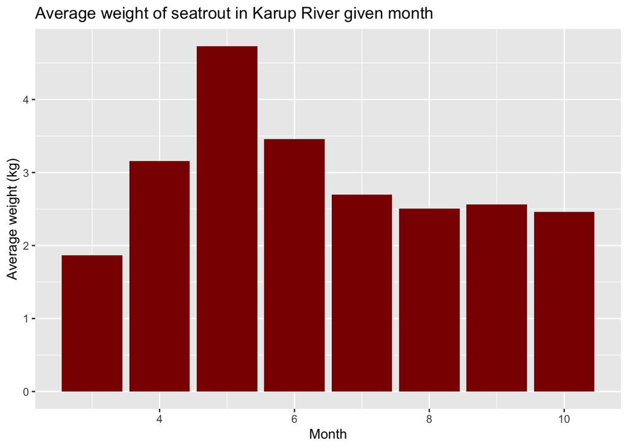

```r
dat_full |>
   filter(River == "Karup", Species == "Seatrout") |>
   group_by(Month) |>
   summarize(
      avg_weight = mean(Weight, na.rm = TRUE)
   ) |>
   ggplot(aes(x = Month, y = avg_weight)) +
   geom_col(fill = "darkred") +
   labs(
      title = "Average weight of seatrout in Karup River given month",
      x = "Month",
      y = "Average weight (kg)"
   )
```

The month with the highest average weight is May.

## Question 2

Create a visualization showing the relationship between length and weight for all fish caught with the following features:

- Different colours are used for each species.
- Points are used to show the individual catches with some transparency (alpha).
- A trend line is added for each species.
- An informative figure title and axis titles are given.
- The legend is placed at the bottom of the figure.

Are salmon generally heavier than seatrout for a given length? Can salmon reach a higher weight than seatrout?

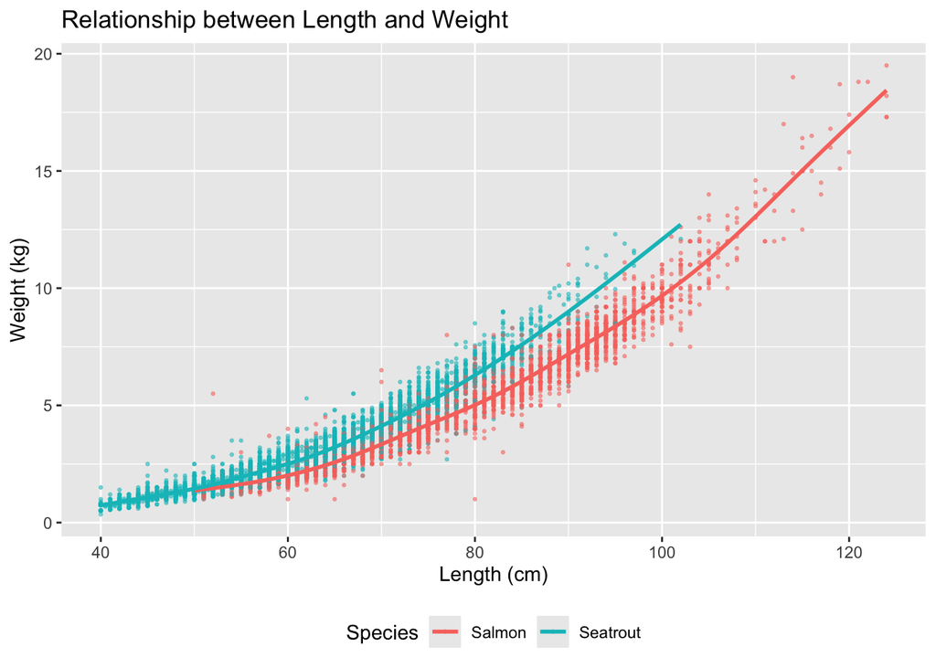

```r
dat |>
   filter(Weight > 0, Length > 0) |>
   ggplot(aes(x = Length, y = Weight, color = Species)) +
   geom_point(alpha = 0.5, size = 0.5) +
   geom_smooth(se = FALSE) +
   labs(
      title = "Relationship between Length and Weight",
      x = "Length (cm)",
      y = "Weight (kg)"
   ) +
   theme(legend.position = "bottom")
```

Salmon are generally NOT heavier than seatrout for a given length as seen from the trend lines. Moreover, salmon can reach a bigger weight than seatrout as seen from the points.

## Question 3

Consider the weight dataset. Create a visualization showing the weight for a given length with the following features:

- Only Skjern River is considered.
- Lines are used to show the average weight given length for each species.
- Different colours are used for each month.
- A subplot is made for each species.
- An informative figure title and axis titles are given.
- The legend is placed at the bottom of the figure.

In which month is the weight lowest for seatrout?

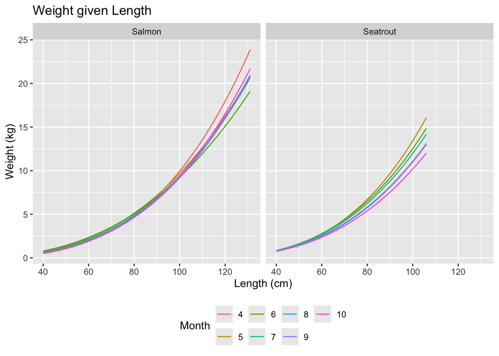

```r
dat_weight |>
   filter(River == "Skjern" ) |>
   ggplot(aes(x = Length, y = Avg, color = factor(Month))) +
   geom_line() +
   facet_wrap(~Species) +
   labs(
      title = "Weight given Length",
      x = "Length (cm)",
      y = "Weight (kg)",
      color = "Month"
   ) +
   theme(legend.position = "bottom")
```

The weight is lowest for seatrout in October (month 10).

## Question 4

Create a visualization showing the percentage of fish over 59 cm killed over the years with the following features:

- Bars are used to visualize the percentage of fish killed.
- Different fill colours are used for each river (use `position = "dodge2"` to place bars beside each other).
- An informative figure title and axis titles are given.
- The legend is placed at the bottom of the figure.

In which river do most anglers catch and release fish (i.e. the lowest percentage killed)?

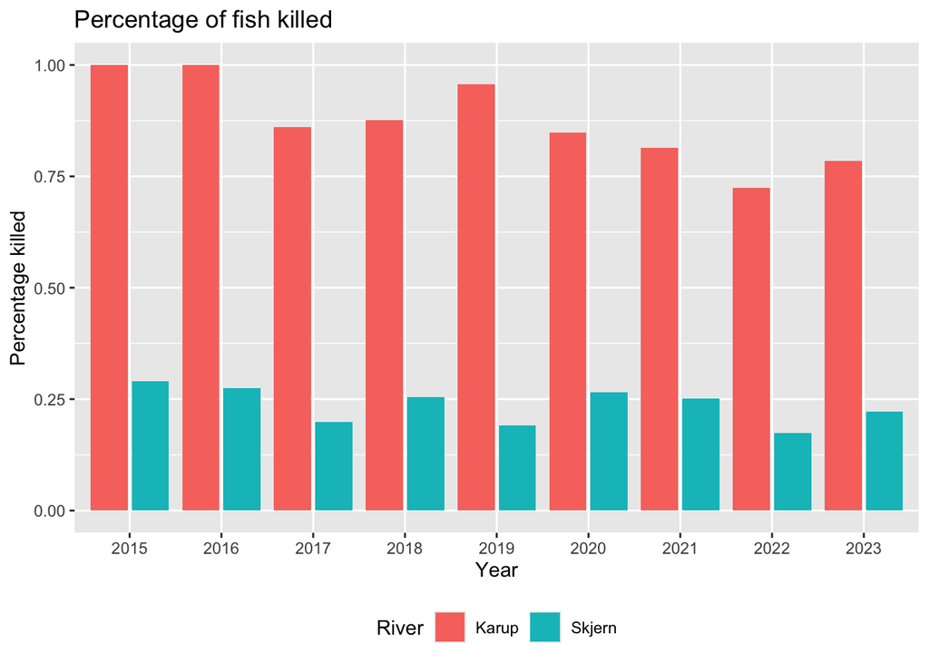

```r
dat |>
   filter(Length >= 60) |>
   group_by(River, Year) |>
   summarize(
      n_caught = n(),
      n_killed = sum(Killed),
      pct_killed = n_killed / n_caught
   ) |>
   ungroup() |>
   ggplot(aes(x = factor(Year), y = pct_killed, fill = River)) +
   geom_col(position = "dodge2") +
   labs(
      title = "Percentage of fish killed",
      x = "Year",
      y = "Percentage killed"
   ) +
   theme(legend.position = "bottom")
```

The river with the most catch and release is Skjern River.

## Question 5

Consider seatrout. For each river, year, and month, calculate the number of catches. Next, calculate the catch percentage for each month (number caught per month / total number caught per year).

```r
res <- dat |>
   filter(Species == "Seatrout") |>
   group_by(River, Year, Month) |>
   summarize(
      n_caught = n()
   ) |>
   group_by(River, Year) |>
   mutate(
      catch_pct = n_caught / sum(n_caught)
   ) |>
   ungroup() |>
   print()
```

```
## # A tibble: 135 × 5
##    River  Year Month n_caught catch_pct
##    <chr> <dbl> <dbl>    <int>     <dbl>
##  1 Karup  2015     3       88   0.0373
##  2 Karup  2015     4       15   0.00636
##  3 Karup  2015     5       40   0.0170
##  4 Karup  2015     6      182   0.0772
##  5 Karup  2015     7      755   0.320
##  6 Karup  2015     8      627   0.266
##  7 Karup  2015     9      328   0.139
##  8 Karup  2015    10      324   0.137
##  9 Karup  2016     3      128   0.0785
## 10 Karup  2016     4       18   0.0110
## # ℹ 125 more rows
```

Create a visualization showing the variation in these percentages for each month with the following features:

- A boxplot is used to show the variation of the catch percentages.
- A subplot is made for each River.
- An informative figure title and axis titles are given.

Comment on the results for July.

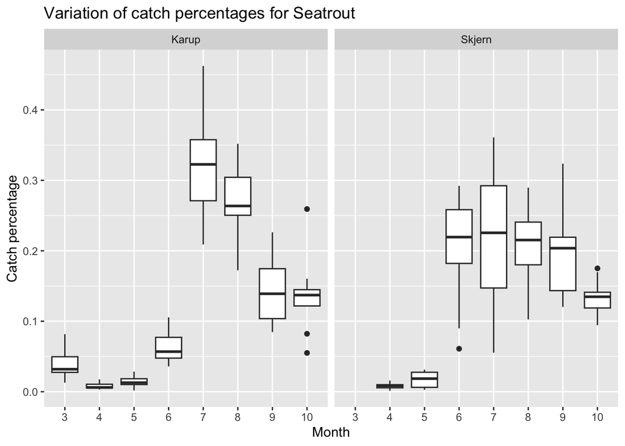

```r
res |>
   ggplot(aes(x = factor(Month), y = catch_pct)) +
   geom_boxplot() +
   facet_wrap(~River) +
   labs(
      title = "Variation of catch percentages for Seatrout",
      x = "Month",
      y = "Catch percentage"
   ) +
   theme(legend.position = "bottom")
```

In July the catch percentage seems to be higher in Karup River compared to Skjern River (the median is higher). However, there is a larger variation in Skjern River (over years).